# Final Project: Predicting Auto Insurance Fraud

Shannon Downey

December 20, 2018

## Project Introduction

- Predicting whether or not an auto insurance claim is fraudulent based on historical data
- It is important to predict fraud to help save companies money. Billions of dollars are lost due to fraud every year, so proactively predicting fraud will help to minimize this loss.
- Dataset was designed to give students practice with predictive modeling; however, there are many insurance companies using this process to predict fraud within their own company

## The Dataset Introduction

- Was extracted from an insurance company’s claim database
- Case was presented at the 2018 EDSIG Conference on Information Systems & Computing Education
- 5001 observations
- Target variable: Fraudulent Claim
- 17 kept input variables: 11 categorical, 6 numeric

## List of Input Variables

- State Code
- Claim Amount
- Education (highest level)
- Claim Date
- Employment Status
- Gender
- Income
- Location (Residential, Suburban, Urban)
- Marital Status
- Annual Premium
- Months Since Last Claim
- Months Since Policy Inception

## Input Variables cont.

- Claim Cause
- Claim Report Type
- Vehicle Class
- Vehicle Size
- Outsanding Balance (how much is left to pay off on the car)
- Dropped variables: Claimant Number, State, Monthly Premium, and Vehicle Model

## Reading in the data and dropping variables

```r
fraud = read.csv('claim_data_v2_train.csv')

names(fraud)[21]='target'
fraud$Claimant__Number=NULL
fraud$State=NULL
fraud$Monthly_Premium=NULL
fraud$Vehicle_Model=NULL

nrow(fraud)
```

```
## [1] 5001
```

## Graph of Fraudulent Claims

There are a lot more legitimate claims than fraudulent ones

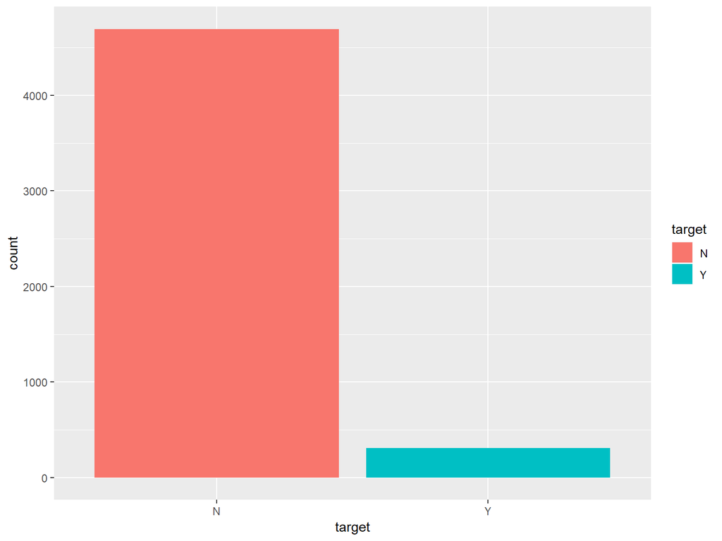

```r
ggplot(data=fraud)+geom_bar(mapping=aes(x=target, fill=target))
```

## Graph of States

There are more claims filed in Iowa, and the least in Kansas

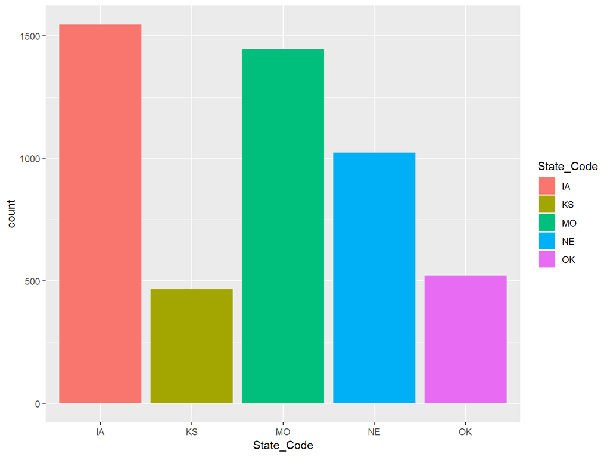

```r
ggplot(data=fraud)+geom_bar(mapping=aes(x=State_Code, fill=State_Code))
```

## Graph of Months Since Policy Inception

Months Since Policy Inception has a pretty uniform distibution

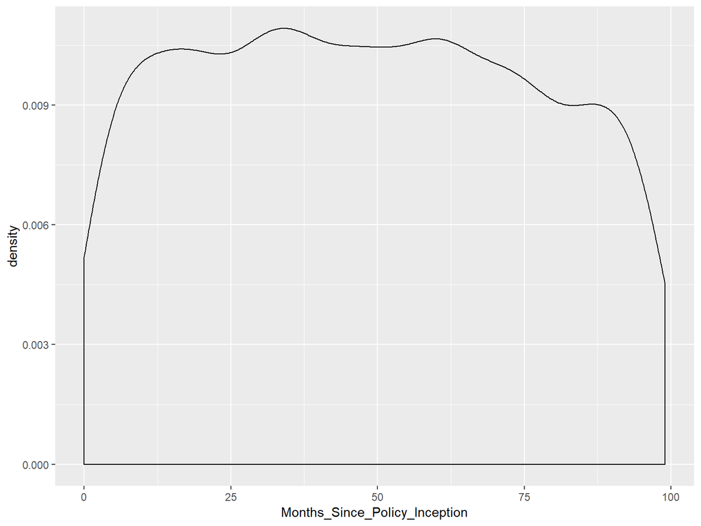

```r
ggplot(data=fraud)+geom_density(mapping=aes(x=Months_Since_Policy_Inception))
```

## Graph of Fraud by State

Iowa and Missouri have the most fraudulent claims

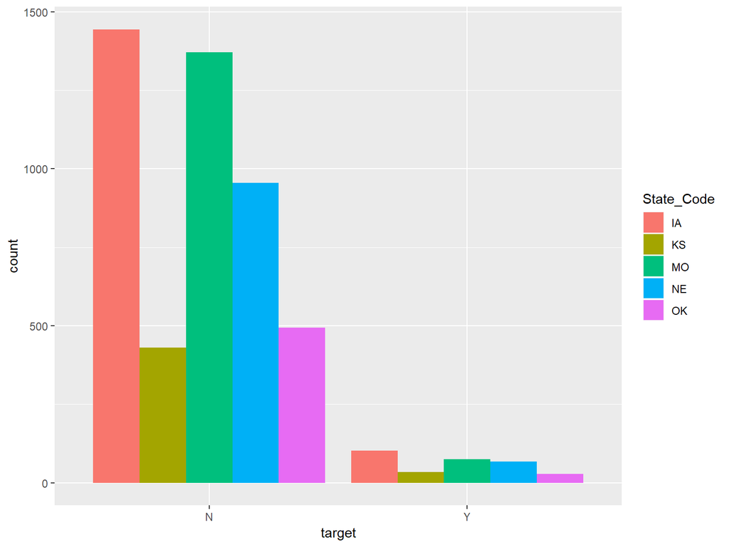

```r
ggplot(data=fraud)+geom_bar(mapping=aes(x=target,fill=State_Code),position="dodge")
```

## Graph of Fraud by Education level

Masters and Doctorates have the least fraudulent claims

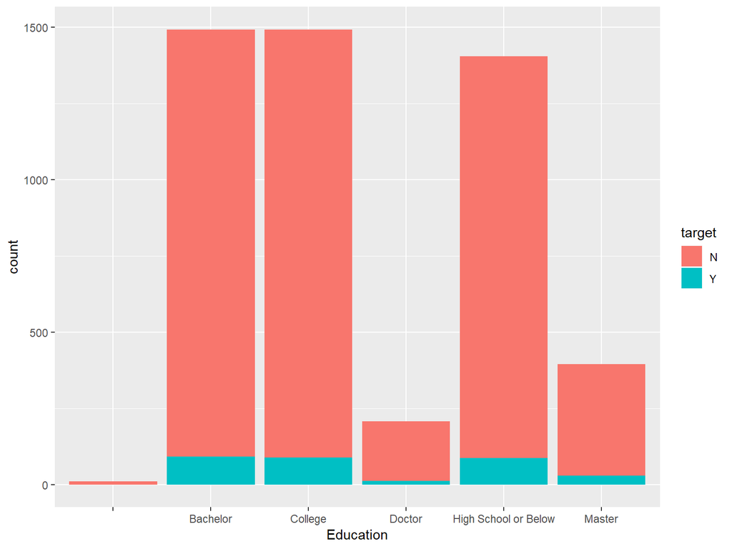

```r
ggplot(data=fraud)+geom_bar(mapping=aes(x=Education,fill=target))
```

## Graph of Fraud by Gender

Males make more fraudulent claims

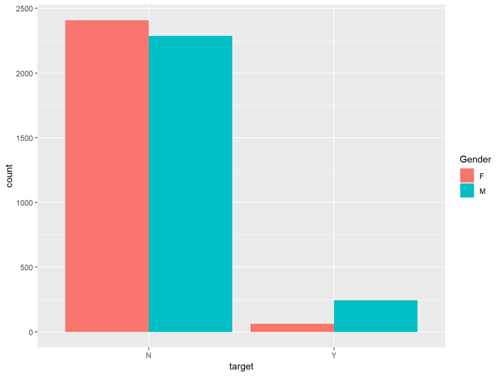

```r
ggplot(data=fraud)+geom_bar(mapping=aes(x=target,fill=Gender),position="dodge")
```

## Graph of Fraud by Employment Status

The unemployed have the highest concentration of fraud

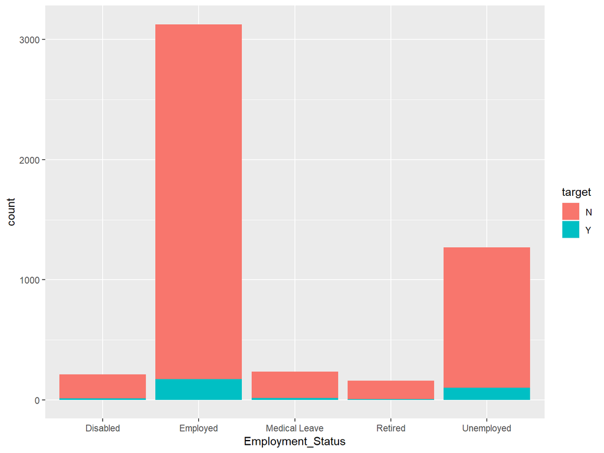

```r
ggplot(data=fraud)+geom_bar(mapping=aes(x=Employment_Status,fill=target))
```

## Graph of Fraud by Location

People who live in suburbs make more fraudulant claims

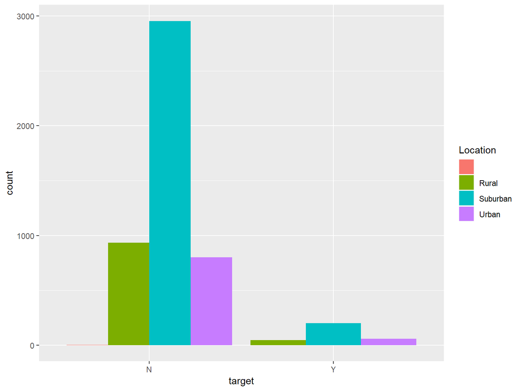

```r
ggplot(data=fraud)+geom_bar(mapping=aes(x=target,fill=Location),position="dodge")
```

## Graph of Fraud by Marital Status

Divorced people make the least amount of fraudulent claims

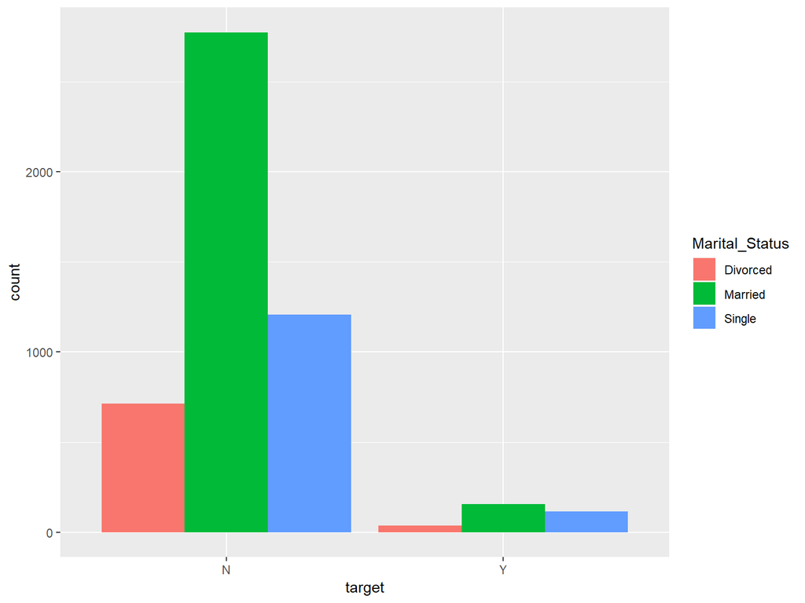

```r
ggplot(data=fraud)+geom_bar(mapping=aes(x=target,fill=Marital_Status),position="dodge")
```

## Graph of Fraud by Claim Cause

Hail claims are the most likely to be fraudulent

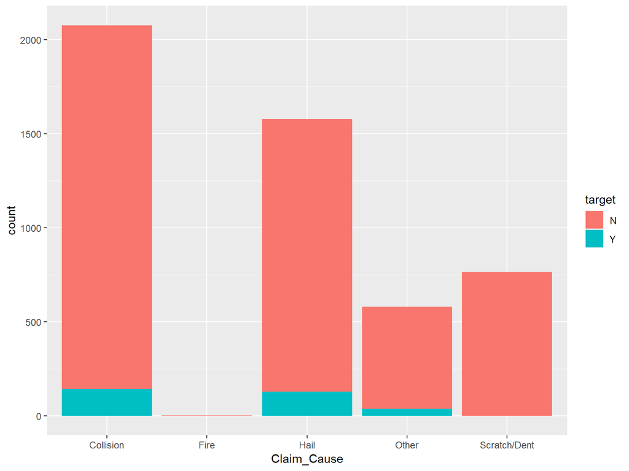

```r
ggplot(data=fraud)+geom_bar(mapping=aes(x=Claim_Cause,fill=target))
```

## Graph of Fraud by Months Since Policy Inception

Fraudulent claims tend to have a policy that is 2-4 years old

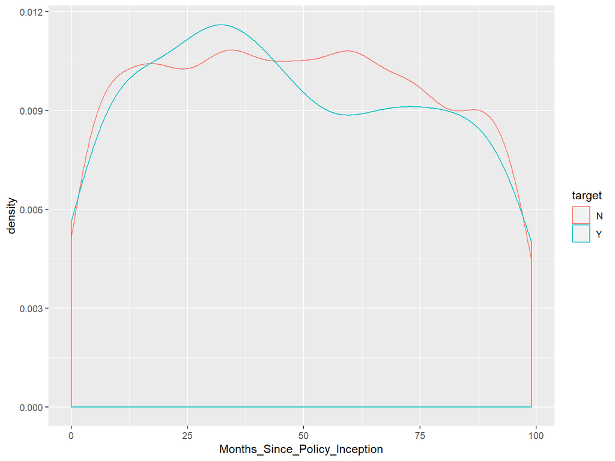

```r
ggplot(data=fraud)+geom_density(mapping=aes(x=Months_Since_Policy_Inception,color=target))
```

## Graph of Fraud by Claim Amount

Claim amount does not seem to be a factor in fraud

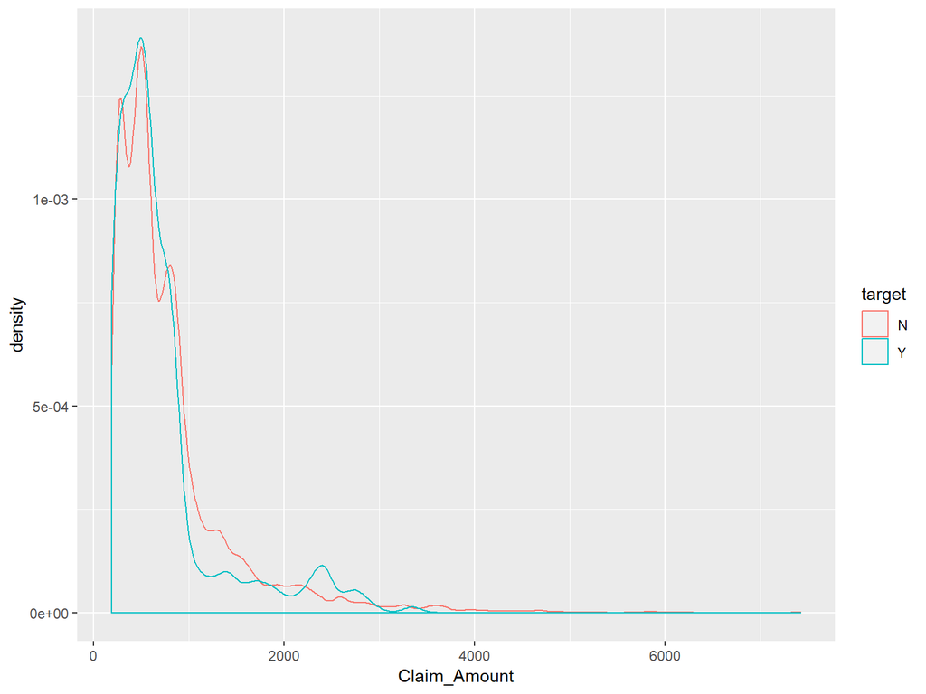

```r
ggplot(data=fraud)+geom_density(mapping=aes(x=Claim_Amount,color=target))
```

## Graph of Fraud by Annual Premium

Mid to upper annual premiums have the most fraudulent claims

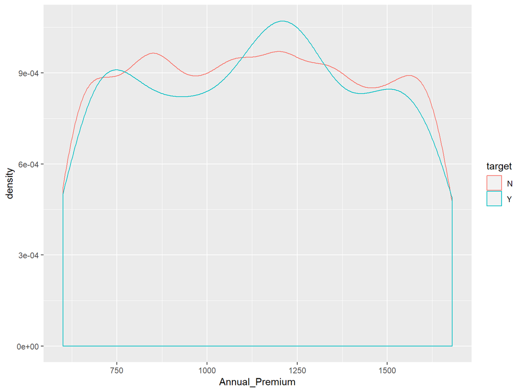

```r
ggplot(data=fraud)+geom_density(mapping=aes(x=Annual_Premium,color=target))
```

## Graph of Fraud by Months Since Last Claim

Lower levels of this varible have the highest concentration of frauds

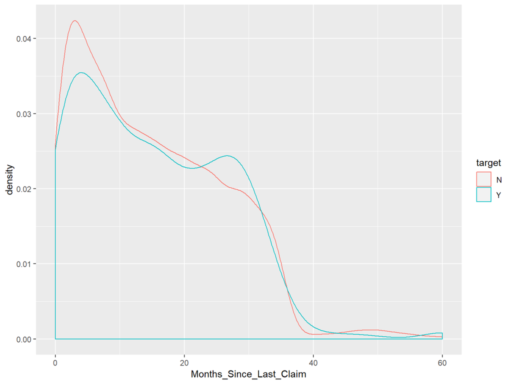

```r
ggplot(data=fraud)+geom_density(mapping=aes(x=Months_Since_Last_Claim,color=target))
```

## Graph of Months Since Policy Inception and Last Claim by Fraud

There does not seem to be a relationship between these 3 variables

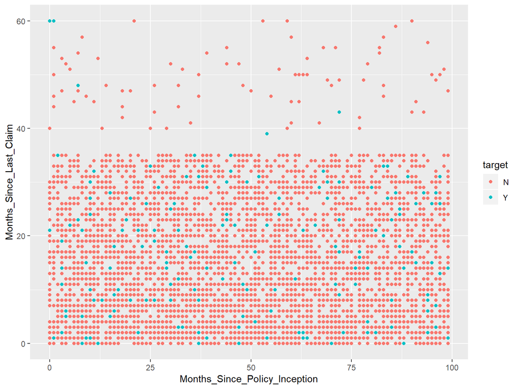

```r
ggplot(data=fraud)+geom_point(mapping=aes(x=Months_Since_Policy_Inception,y=Months_Since_Last_Claim,color=target))
```

## Handling missing values #1

Before imputing, I first needed to label any values that were just a space as missing. The first way to handle missing values is to simply remove rows that have them.

```r
fraud[fraud=='']=NA
sum(is.na(fraud))
```

```
## [1] 23
```

```r
fraud_remove=fraud[complete.cases(fraud),]
fraud_remove$target=as.factor(fraud_remove$target)
sum(is.na(fraud_remove))
```

```
## [1] 0
```

## Handling missing values #2

The second way to handle missing values is to impute numeric missing values with the median and catergorical values with the mode

```r
imputer=function(x){
  if(!is.numeric(x)){
    levels=unique(x)
    x[is.na(x)]=levels[which.max(table(x))]
  }
  return(x)
}

median=preProcess(fraud, method='medianImpute')
fraud_med=predict(median, newdata = fraud)
fraud_med=data.frame(lapply(fraud_med,imputer))
sum(is.na(fraud_med))
```

```
## [1] 0
```

## Handling missing values #3

The third way to handle missing values is to impute numeric missing values with a constant (0 in this case) and catergorical values with the mode

```r
imputer2=function(x){
  if(is.numeric(x)){
    x[is.na(x)]=0
  }else{
    levels=unique(x)
    x[is.na(x)]=levels[which.max(table(x))]
  }
  return(x)
}

fraud_mean=data.frame(lapply(fraud,imputer2))
sum(is.na(fraud_mean))
```

```
## [1] 0
```

## Recoding Claim Date

```r
fraud_rm_recoded=fraud_remove
fraud_med_recoded=fraud_med
fraud_mean_recoded=fraud_mean
library(car)
Jan.set=c("01/15/2019")
Dec.set=c("12/01/2018", "12/15/2018")

fraud_rm_recoded$Claim_Date=recode(fraud_rm_recoded$Claim_Date,"Jan.set='Jan'; Dec.set='Dec'")
fraud_med_recoded$Claim_Date=recode(fraud_med_recoded$Claim_Date,"Jan.set='Jan'; Dec.set='Dec'")
fraud_mean_recoded$Claim_Date=recode(fraud_mean_recoded$Claim_Date,"Jan.set='Jan'; Dec.set='Dec'")
```

## Recoding Education level

```r
Advanced.set=c("Doctor","Master")

fraud_rm_recoded$Education=recode(fraud_rm_recoded$Education,"Advanced.set='Advanced'")
fraud_med_recoded$Education=recode(fraud_med_recoded$Education,"Advanced.set='Advanced'")
fraud_mean_recoded$Education=recode(fraud_mean_recoded$Education,"Advanced.set='Advanced'")
```

## Recoding Employment Status

```r
Med_probs.set=c("Disabled","Medical Leave")

fraud_rm_recoded$Employment_Status=recode(fraud_rm_recoded$Employment_Status,"Med_probs.set='Med probs'")
fraud_med_recoded$Employment_Status=recode(fraud_med_recoded$Employment_Status,"Med_probs.set='Med probs'")
fraud_mean_recoded$Employment_Status=recode(fraud_mean_recoded$Employment_Status,"Med_probs.set='Med probs'")
```

## Recoding Claim Cause

```r
Weather.set=c("Fire","Hail")

fraud_rm_recoded$Claim_Cause=recode(fraud_rm_recoded$Claim_Cause,"Weather.set='Weather'")
fraud_med_recoded$Claim_Cause=recode(fraud_med_recoded$Claim_Cause,"Weather.set='Weather'")
fraud_mean_recoded$Claim_Cause=recode(fraud_mean_recoded$Claim_Cause,"Weather.set='Weather'")
```

## Recoding Vehicle Class

```r
Luxury.set=c("Luxury Car", "Luxury SUV")

fraud_rm_recoded$Vehicle_Class=recode(fraud_rm_recoded$Vehicle_Class,"Luxury.set='Luxury'")
fraud_med_recoded$Vehicle_Class=recode(fraud_med_recoded$Vehicle_Class,"Luxury.set='Luxury'")
fraud_mean_recoded$Vehicle_Class=recode(fraud_mean_recoded$Vehicle_Class,"Luxury.set='Luxury'")
```

## Encoding Binary Variables

```r
fraud_rm_recoded$target=ifelse(fraud_rm_recoded$target=="Y","1","0")
fraud_rm_recoded$Gender=ifelse(fraud_rm_recoded$Gender=="F",1,0)

fraud_med_recoded$target=ifelse(fraud_med_recoded$target=="Y","1","0")
fraud_med_recoded$Gender=ifelse(fraud_med_recoded$Gender=="F",1,0)

fraud_mean_recoded$target=ifelse(fraud_mean_recoded$target=="Y","1","0")
fraud_mean_recoded$Gender=ifelse(fraud$Gender=="F",1,0)
```

## Encoding using Dummy Variables

```r
dummies_rm=dummyVars(target ~ ., data=fraud_rm_recoded)
fraud_rm_dummies=predict(dummies_rm, newdata = fraud_rm_recoded)
fraud_rm_dummies= data.frame(fraud_rm_dummies)
fraud_rm_dummies$target=fraud_rm_recoded$target

dummies_med=dummyVars(target ~ ., data=fraud_med_recoded)
fraud_med_dummies=predict(dummies_med, newdata = fraud_med_recoded)
fraud_med_dummies= data.frame(fraud_med_dummies)
fraud_med_dummies$target=fraud_med_recoded$target

dummies_mean=dummyVars(target ~ ., data=fraud_mean_recoded)
fraud_mean_dummies=predict(dummies_mean, newdata = fraud_mean_recoded)
fraud_mean_dummies= data.frame(fraud_mean_dummies)
fraud_mean_dummies$target=fraud_mean_recoded$target

fraud_rm_dummies$target=as.factor(fraud_rm_dummies$target)
fraud_med_dummies$target=as.factor(fraud_med_dummies$target)
fraud_mean_dummies$target=as.factor(fraud_mean_dummies$target)
```

## Encoding using as.numeric

```r
encode=function(x){
  if(!is.numeric(x)){
      x=as.numeric(x)
  }
  return(x)
}

fraud_rm_encoded=data.frame(lapply(fraud_rm_recoded,encode))
fraud_med_encoded=data.frame(lapply(fraud_med_recoded,encode))
fraud_mean_encoded=data.frame(lapply(fraud_mean_recoded,encode))

fraud_rm_encoded$target=as.factor(fraud_rm_encoded$target)
fraud_med_encoded$target=as.factor(fraud_med_encoded$target)
fraud_mean_encoded$target=as.factor(fraud_mean_encoded$target)
```

## Partitioning the data with dummy variables

```r
set.seed(2018)
splitIndex1=createDataPartition(fraud_rm_dummies$target,p=.70, list=FALSE, times=1)
rm_dummies_train=fraud_rm_dummies[splitIndex1,]
rm_dummies_test=fraud_rm_dummies[-splitIndex1,]

splitIndex2=createDataPartition(fraud_med_dummies$target,p=.70, list=FALSE, times=1)
med_dummies_train=fraud_med_dummies[splitIndex2,]
med_dummies_test=fraud_med_dummies[-splitIndex2,]

splitIndex3=createDataPartition(fraud_mean_dummies$target,p=.70, list=FALSE, times=1)
mean_dummies_train=fraud_mean_dummies[splitIndex3,]
mean_dummies_test=fraud_mean_dummies[-splitIndex3,]
```

## Partitioning the numeric data

```r
set.seed(2018)
splitIndex4=createDataPartition(fraud_rm_encoded$target,p=.70, list=FALSE, times=1)
rm_encoded_train=fraud_rm_encoded[splitIndex4,]
rm_encoded_test=fraud_rm_encoded[-splitIndex4,]

splitIndex5=createDataPartition(fraud_med_encoded$target,p=.70, list=FALSE, times=1)
med_encoded_train=fraud_med_encoded[splitIndex5,]
med_encoded_test=fraud_med_encoded[-splitIndex5,]

splitIndex6=createDataPartition(fraud_mean_encoded$target,p=.70, list=FALSE, times=1)
mean_encoded_train=fraud_mean_encoded[splitIndex6,]
mean_encoded_test=fraud_mean_encoded[-splitIndex6,]
```

## Balancing the train data

```r
undersample=function(x){
  train1=x[x[,'target']=="1",]
  n1=nrow(train1)

  train0=x[x[,'target']=="0",]
  n0=nrow(train0)

  train00=train0[sample(1:n0,n1),]
  return (rbind(train00,train1))

}

rm_dummies_train=undersample(rm_dummies_train)
med_dummies_train=undersample(med_dummies_train)
mean_dummies_train=undersample(mean_dummies_train)
rm_encoded_train=undersample(rm_encoded_train)
med_encoded_train=undersample(med_encoded_train)
mean_encoded_train=undersample(mean_encoded_train)
```

## Building models on the dummy variable data

```r
tree_rm_dummies=train(target~.,data=rm_dummies_train,method="rpart")
forest_rm_dummies=train(target~.,data=rm_dummies_train,method="ranger")
nnet_rm_dummies=train(target~.,data=rm_dummies_train,method="nnet")
glm_rm_dummies=train(target~.,data=rm_dummies_train, method="glmnet")

tree_med_dummies=train(target~.,data=med_dummies_train,method="rpart")
forest_med_dummies=train(target~.,data=med_dummies_train,method="ranger")
nnet_med_dummies=train(target~.,data=med_dummies_train,method="nnet")
glm_med_dummies=train(target~.,data=med_dummies_train, method="glmnet")

tree_mean_dummies=train(target~.,data=mean_dummies_train,method="rpart")
forest_mean_dummies=train(target~.,data=mean_dummies_train,method="ranger")
nnet_mean_dummies=train(target~.,data=mean_dummies_train,method="nnet")
glm_mean_dummies=train(target~.,data=mean_dummies_train, method="glmnet")
```

## Building models on the encoded data

```r
tree_rm_encoded=train(target~.,data=rm_encoded_train,method="rpart")
forest_rm_encoded=train(target~.,data=rm_encoded_train,method="ranger")
nnet_rm_encoded=train(target~.,data=rm_encoded_train,method="nnet")
glm_rm_encoded=train(target~.,data=rm_encoded_train, method="glmnet")

tree_med_encoded=train(target~.,data=med_encoded_train,method="rpart")
forest_med_encoded=train(target~.,data=med_encoded_train,method="ranger")
nnet_med_encoded=train(target~.,data=med_encoded_train,method="nnet")
glm_med_encoded=train(target~.,data=med_encoded_train, method="glmnet")

tree_mean_encoded=train(target~.,data=mean_encoded_train,method="rpart")
forest_mean_encoded=train(target~.,data=mean_encoded_train,method="ranger")
nnet_mean_encoded=train(target~.,data=mean_encoded_train,method="nnet")
glm_mean_encoded=train(target~.,data=mean_encoded_train, method="glmnet")
```

## Creating tuning grids for each model

```r
forestGrid=expand.grid(mtry=c(1:3),splitrule=c("gini","extratrees"),min.node.size=c(1:4))
treeTrain=trainControl(method ="cv", number = 5, verboseIter = TRUE)
nnetGrid=expand.grid(size = seq(from = 1, to = 3, by = 1),decay = seq(from = 0.1, to = 0.3, by = 0.1))
glmGrid=expand.grid(.alpha=0:1,.lambda=seq(0.001,1,length=10))
```

## Running tuned models on dummy variables data

```r
tree2_rm_dummies=train(target~.,data=rm_dummies_train,method="rpart",trControl=treeTrain)
forest2_rm_dummies=train(target~.,data=rm_dummies_train,method="ranger",trControl=treeTrain,tuneGrid=forestGrid)
nnet2_rm_dummies=train(target~.,data=rm_dummies_train,method="nnet",tuneGrid=nnetGrid)
glm2_rm_dummies=train(target~.,data=rm_dummies_train, method="glmnet",tuneGrid=glmGrid)
tree2_med_dummies=train(target~.,data=med_dummies_train,method="rpart",trControl=treeTrain)
forest2_med_dummies=train(target~.,data=med_dummies_train,method="ranger",trControl=treeTrain,tuneGrid=forestGrid)
nnet2_med_dummies=train(target~.,data=med_dummies_train,method="nnet",tuneGrid=nnetGrid)
glm2_med_dummies=train(target~.,data=med_dummies_train, method="glmnet",tuneGrid=glmGrid)
tree2_mean_dummies=train(target~.,data=mean_dummies_train,method="rpart",trControl=treeTrain)
forest2_mean_dummies=train(target~.,data=mean_dummies_train,method="ranger",trControl=treeTrain,tuneGrid=forestGrid)
nnet2_mean_dummies=train(target~.,data=mean_dummies_train,method="nnet",tuneGrid=nnetGrid)
glm2_mean_dummies=train(target~.,data=mean_dummies_train,method="glmnet",tuneGrid=glmGrid)
```

## Running tuned models on encoded data

```r
tree2_rm_encoded=train(target~.,data=rm_encoded_train,method="rpart",trControl=treeTrain)
forest2_rm_encoded=train(target~.,data=rm_encoded_train,method="ranger",trControl=treeTrain,tuneGrid=forestGrid)
nnet2_rm_encoded=train(target~.,data=rm_encoded_train,method="nnet",tuneGrid=nnetGrid)
glm2_rm_encoded=train(target~.,data=rm_encoded_train, method="glmnet",tuneGrid=glmGrid)
tree2_med_encoded=train(target~.,data=med_encoded_train,method="rpart",trControl=treeTrain)
forest2_med_encoded=train(target~.,data=med_encoded_train,method="ranger",trControl=treeTrain,tuneGrid=forestGrid)
nnet2_med_encoded=train(target~.,data=med_encoded_train,method="nnet",tuneGrid=nnetGrid)
glm2_med_encoded=train(target~.,data=med_encoded_train,method="glmnet",tuneGrid=glmGrid)
tree2_mean_encoded=train(target~.,data=mean_encoded_train,method="rpart",trControl=treeTrain)
forest2_mean_encoded=train(target~.,data=mean_encoded_train,method="ranger",trControl=treeTrain,tuneGrid=forestGrid)
nnet2_mean_encoded=train(target~.,data=mean_encoded_train,method="nnet",tuneGrid=nnetGrid)
glm2_mean_encoded=train(target~.,data=mean_encoded_train,method="glmnet",tuneGrid=glmGrid)
```

## Choosing the best model–list of all the models

```r
models=list(tree_rm_dummies,tree_med_dummies,tree_mean_dummies,tree_rm_encoded,
            tree_med_encoded,tree_mean_encoded,forest_rm_dummies,forest_med_dummies,
            forest_mean_dummies,forest_rm_encoded,forest_med_encoded,
            forest_mean_encoded,
            nnet_rm_dummies,nnet_med_dummies,nnet_mean_dummies,nnet_rm_encoded,
            nnet_med_encoded,nnet_mean_encoded,glm_rm_dummies,glm_med_dummies,
            glm_mean_dummies,glm_rm_encoded,glm_med_encoded,glm_mean_encoded,
            tree2_rm_dummies,tree2_med_dummies,tree2_mean_dummies,tree2_rm_encoded,
            tree2_med_encoded,tree2_mean_encoded,forest2_rm_dummies,forest2_med_dummies,
            forest2_mean_dummies,forest2_rm_encoded,forest2_med_encoded,
            forest2_mean_encoded,nnet2_rm_dummies,nnet2_med_dummies,nnet2_mean_dummies,
            nnet2_rm_encoded,nnet2_med_encoded,nnet2_mean_encoded,glm2_rm_dummies,
            glm2_med_dummies,glm2_mean_dummies,glm2_rm_encoded,glm2_med_encoded,
            glm2_mean_encoded)
```

## Choosing the best model–list of all the model names

```r
names=list("Tree Dummies Remove","Tree Dummies MedImp","Tree Dummies MeanImp",
           "Tree Encoded Remove","Tree Encoded Remove","Tree Encoded Remove",
           "Forest Dummies Remove","Forest Dummies MedImp","Forest Dummies MeanImp",
           "Forest Encoded Remove","Forest Encoded Remove","Forest Encoded Remove",
           "NNet Dummies Remove","NNet Dummies MedImp","NNet Dummies MeanImp",
           "NNet Encoded Remove","NNet Encoded Remove","NNet Encoded Remove",
           "GLM Dummies Remove","GLM Dummies MedImp","GLM Dummies MeanImp",
           "GLM Encoded Remove","GLM Encoded Remove","GLM Encoded Remove",
           "Tree2 Dummies Remove","Tree2 Dummies MedImp","Tree2 Dummies MeanImp",
           "Tree2 Encoded Remove","Tree2 Encoded Remove","Tree2 Encoded Remove",
           "Forest2 Dummies Remove","Forest2 Dummies MedImp","Forest2 Dummies MeanImp",
           "Forest2 Encoded Remove","Forest2 Encoded Remove","Forest2 Encoded Remove",
           "NNet2 Dummies Remove","NNet2 Dummies MedImp","NNet2 Dummies MeanImp",
           "NNet2 Encoded Remove","NNet2 Encoded Remove","NNet2 Encoded Remove",
           "GLM2 Dummies Remove","GLM2 Dummies MedImp","GLM2 Dummies MeanImp",
           "GLM2 Encoded Remove","GLM2 Encoded Remove","GLM2 Encoded Remove")
```

## Choosing the best model–list of all the testing data

```r
test_data=list(rm_dummies_test,med_dummies_test,mean_dummies_test,rm_encoded_test,
               med_encoded_test,mean_encoded_test,rm_dummies_test,med_dummies_test,
               mean_dummies_test,rm_encoded_test,med_encoded_test,mean_encoded_test,
               rm_dummies_test,med_dummies_test,mean_dummies_test,rm_encoded_test,
               med_encoded_test,mean_encoded_test,rm_dummies_test,med_dummies_test,
               mean_dummies_test,rm_encoded_test,med_encoded_test,mean_encoded_test,
               rm_dummies_test,med_dummies_test,mean_dummies_test,rm_encoded_test,
               med_encoded_test,mean_encoded_test,rm_dummies_test,med_dummies_test,
               mean_dummies_test,rm_encoded_test,med_encoded_test,mean_encoded_test,
               rm_dummies_test,med_dummies_test,mean_dummies_test,rm_encoded_test,
               med_encoded_test,mean_encoded_test,rm_dummies_test,med_dummies_test,
               mean_dummies_test,rm_encoded_test,med_encoded_test,mean_encoded_test)
```

## Choosing the best model based on Balanced Accuracy

```r
compare=c()
prediction=function(model, test){
  pred=predict(model,test)
  cm=confusionMatrix(pred,test[,'target'],positive="1")
  compare=c(compare,cm$byClass['Balanced Accuracy'])
}

accuracies=mapply(prediction, models, test_data)
best=max(accuracies)
index=match(best,accuracies)
best_model_name=names[[index]]
best_model=models[[index]]
```

## Conclusion

```r
paste("Best Model: ",best_model_name)
```

```
## [1] "Best Model:  GLM2 Dummies Remove"
```

```r
paste("Balanced Accuracy: ",best)
```

```
## [1] "Balanced Accuracy:  0.790730326062232"
```

## Hyperparameters for the best model

```r
best_model
```

```
## glmnet
##
## 430 samples
##  45 predictor
##   2 classes: '0', '1'
##
## No pre-processing
## Resampling: Bootstrapped (25 reps)
## Summary of sample sizes: 430, 430, 430, 430, 430, 430, ...
## Resampling results across tuning parameters:
##
##   alpha  lambda  Accuracy   Kappa
##   0      0.001   0.7582293  0.5172190
##   0      0.112   0.7545931  0.5109403
##   0      0.223   0.7474511  0.4974058
##   0      0.334   0.7461151  0.4953194
##   0      0.445   0.7450237  0.4934934
##   0      0.556   0.7429103  0.4896906
##   0      0.667   0.7416753  0.4875144
##   0      0.778   0.7358744  0.4764710
##   0      0.889   0.7335086  0.4723218
##   0      1.000   0.7314615  0.4688119
##   1      0.001   0.7569388  0.5141655
##   1      0.112   0.7453024  0.4939966
##   1      0.223   0.4831589  0.0103681
##   1      0.334   0.4776930  0.0000000
##   1      0.445   0.4776930  0.0000000
##   1      0.556   0.4776930  0.0000000
##   1      0.667   0.4776930  0.0000000
##   1      0.778   0.4776930  0.0000000
##   1      0.889   0.4776930  0.0000000
##   1      1.000   0.4776930  0.0000000
##
## Accuracy was used to select the optimal model using the largest value.
## The final values used for the model were alpha = 0 and lambda = 0.001.
```